# Jordan Lake Reservoir Model

Part1: Model simulation for 1983-2018 period

Smitom Borah

04/25/2023

Time required to run the entire notebook: ~3 hrs

# 1 Motivation

The codes in this R notebook are the codes used to prepare the results and discussion in the paper. Most of the codes are taken from the version 10 (and version 15) of this model. A new version was needed as the previous version (version 15) had too many modifications and experimentation, making that version less tractable.

# 2 Edit log

*No new edits since creation*

# 3 Introduction

The mass balance equation for phosphorus in the water column is as follows:

$$\begin{align}
\tag{1}
\frac{dM_i}{dt}=(R_s\times S_i)\theta_R^{T-20}+(Qin_i\times
Cin_i)(1-\psi)-M_i(k+\frac{v\times A_i}{V_i})\theta_V^{T-20}+
Q_{i-1,i}\times\frac{M_{i-1}}{V_{i-1}}-Q_{i,i+1}\times \frac{M_i}{V_i}
\end{align}$$

In case of reverse flow (south to north), the lase two terms are replaced by the following :
$$\begin{align}
\tag{2}
Q_{i+1,i}\times\frac{M_{i+1}}{V_{i+1}}-Q_{i,i-1}\times \frac{M_i}{V_i}
\end{align}$$

The mass balance for phosphorus in the sediments is as follows:
$$\begin{align}
\tag{3}
\frac{dS_i}{dt}=(M_i(k + \frac{v\times
A_i}{V_i}))\theta_V^{T-20}-(R_s\times S_i)\theta_R^{T-20}-(B_r\times
S_i)\theta_R^{T-20}
\end{align}$$

The terms used in the preceding equations are described as follows:

| Terms | Description | Units |
| --- | --- | --- |
| M<sub>i</sub> | Mass of phosphorus in segment i water layer | kg |
| S<sub>i</sub> | Mass of phosphorus in segment i sediment layer | kg |
| v | Transfer rate of nutrients to the sediment layer, as an effective settling velocity | m/month |
| k | Transfer rate of nutrients to the sediment layer, as a first order removal rate | 1/month |
| $\psi$ | Watershed nutrient load adjustment factor | - |
| R<sub>s</sub> | Recycling rate of nutrients from the sediments back into the water layer | 1/month |
| B<sub>r</sub> | Removal rate from the sediment to permanent burial | 1/month |
| $\theta_V$ | Temperature adjustment parameter for the transfer of nutrients from the water column to sediments | - |
| $\theta_R$ | Temperature adjustment parameter for the sediment nutrient recycling rate | - |
| A<sub>i</sub> | Area of segment i water layer at the surface (varies with time) | 10<sup>6</sup>m<sup>2</sup> |
| V<sub>i</sub> | Volume of segment i water layer (varies with time) | 10<sup>6</sup>m<sup>3</sup> |
| Qin<sub>i</sub> | Watershed inflow to segment i(varies with time) | 10<sup>6</sup>m<sup>3</sup>/month |
| Cin<sub>i</sub> | Concentration of phosphorus in watershed inflow(varies with time) | mg/m<sup>3</sup> |
| Q<sub>i-1,i</sub> | Flow from upstream segment to segment i(varies with time) | 10<sup>6</sup>m<sup>3</sup>/month |
| Q<sub>i,i+1</sub> | Flow from segment i to the downstream segment (varies with time) | 10<sup>6</sup>m<sup>3</sup>/month |

# 4 Packages

A number of packages are loaded to run the model. However, there can be some curtailing in their numbers. Not all the packages are equally important for this model to run smoothly. The most important package is the ODIN package which helps us solve differential equations (1 and 3) efficiently.

```r
# SSB: Clearing the global environment----
# rm(list = ls())
cat("\014"); rm(list=ls(all=TRUE)); graphics.off()
```

```r
# Start timer
Start_timer1 <- Sys.time()
```

```r
# Loading packages----
# DDG: ODIN cannot be installed like other packages and requires this process
if (!require("pacman")) install.packages("pacman");pacman::p_load(shinyjs,threejs,brms,minpack.lm,MuMIn,lme4, penalized,zoo,RColorBrewer,
  gridExtra,rowr,stringi,optimx,Hmisc,leaps,caret,magrittr,plotly,remotes,RcppRoll,suncalc,adaptMCMC,TTR, truncnorm, readxl,lubridate, data.table,deSolve,zoo,tidyverse,gridExtra, viridis, RColorBrewer)


# SSB : To print all the columns of the tibble
options(tibble.width = Inf)
```

# 5 Input data

## 5.1 loading input files

The data required for this model has been stored in a number of files. These files are stored in other folders such as OutputFiles, DataFiles and RWorkSpaces. Following are the files required to run the model:

- Model Inputs Processed V5.csv
- PcalMidM_no19v2.RData
- functionsJorLak_no19.R
- TP Monthly Watershed Loading_dro 11_15.xlsx
- lakeOmidM_no19v2.csv

*Note:* Please ensure that the working directory is where the project is stored. To change: Tools > Global Options… > R Markdown > Evaluate chunks in directory ‘Project’.

```r
# Loading the input files ----
# Seed value
eff_se1 <- 5000

# DDG: can load previous MCMC results
load("RWorkSpaces/PcalMidM_no19v2.RData")


# the previous optimum parameters as the initial values.
prev_opt <- opt_prm

# Hydrological model input; data based on SSB's values
RoutMOdin <- read_excel('DataFiles/Model Inputs Processed V5.xlsx', sheet = "Model Inputs Processed V5")

RoutMOdin$yrmo <- paste0(RoutMOdin$mo,"/",RoutMOdin$year)

RoutMOdin = RoutMOdin %>% arrange(t)#don't let it sort by "yrmo" like it defaults to

# DDG: start and end month of simulation
st.mo="1/1983"
end.mo="12/2018"


# total number of years
tmax=which(RoutMOdin[,"yrmo"]==end.mo)-which(RoutMOdin[,"yrmo"]==st.mo)+1 # DDG: add 1 for inclusive period

# Rearranging RoutMOdin
RoutMOdin=RoutMOdin[(which(RoutMOdin[,"yrmo"]==st.mo)):which(RoutMOdin[,"yrmo"]==end.mo),]

# SSB: the t column is reassigned to have continuously increasing natural numbers
RoutMOdin$t = c(1:tmax)


# DDG: transformation parameters here for box-cox transformation
l1 = 0
l2 = 0

# DDG: custom functions loaded here
suppressMessages(source("Pmodels/JLPMfunv16p001.R"))  # Same as functionsJorLak_Aug22.R but renamed

# Fix watersheds concentrations using Dn's spreadsheet(inspiration: sceChl_oc19)
read_excel("DataFiles/TP Monthly Watershed Loading_dro 11_15.xlsx",'Segment loads', range = "A2:S434",col_names =T) %>%
  dplyr::select(yrmo,C1in,C2in,C3in,C4in) -> updConc

# SSB: Adding the correct inflow P concentration
RoutMOdin %<>% dplyr::select(-C1in,-C2in,-C3in,-C4in) %>%
  left_join(.,updConc)

# Processed observed lacustrine data
data_file <- "DataFiles/lakeOmidM_no19v2.csv"
obs <- read_csv(data_file) %>%
  transmute(ym=factor(paste(month(cale_date),year(cale_date),sep="/")),
    obs=sePmo,variable=paste0("C",readr::parse_number(segm))) %>%
  drop_na()
```

# 6 Stratification: Surface modifiers

To incorporate stratification in the model indirectly, we developed random forest models for each segment to simulate bottom-to-surface P ratios and the coefficient of determination of the models ranged 0.28 to 0.5. More importantly, the seasonal median of the predicted values were similar to the observed seasonal mean, which gave us confidence to go ahead and use these model.The model outputs are stored in the following csv files:

- predBoSuP_Seg2RF4.csv
- predBoSuP_Seg3RF4.csv
- predBoSuP_Seg4RF4.csv

```r
# get segment 2, 3, and 4 data:
Seg2_BoSuP <- read.csv('DataFiles/predBoSuP_Seg2RF4.csv')
Seg3_BoSuP <- read.csv('DataFiles/predBoSuP_Seg3RF4.csv')
Seg4_BoSuP <- read.csv('DataFiles/predBoSuP_Seg4RF4.csv')

# Getting the date and bottom to surface P ratios in one data frame
BoSuP_df <- merge(Seg2_BoSuP[,c("Date", "pred_BoSuP")],
                  Seg3_BoSuP[,c("Date", "pred_BoSuP")],
                  by = "Date")
BoSuP_df <- BoSuP_df %>% rename(.,
                                Seg2_Rp = pred_BoSuP.x,
                                Seg3_Rp = pred_BoSuP.y)

BoSuP_df <- merge(BoSuP_df, Seg4_BoSuP[,c("Date", "pred_BoSuP")], by = "Date" )
BoSuP_df$Date <- as.Date(BoSuP_df$Date)
BoSuP_df <- BoSuP_df %>% rename(.,
                                Seg4_Rp = pred_BoSuP)



## Calculating the monthly median
BoSuP_df <- BoSuP_df %>% mutate(Month = month(Date),
                                Year = year(Date))
BoSuP_MoDf <- BoSuP_df %>%
  group_by(Year, Month) %>%
  summarise(Seg2_Rp = median(Seg2_Rp),
            Seg3_Rp = median(Seg3_Rp),
            Seg4_Rp = median(Seg4_Rp)) %>%
  mutate(yrmo = paste0(Month,"/",Year))

BoSuP_MoDf <- BoSuP_MoDf[which(BoSuP_MoDf$yrmo %in% RoutMOdin$yrmo),]


## Simulated ratios of Segments 2, 3 and 4
ConSurM=data.frame(matrix(vector(),tmax,3,dimnames=list(c(), c("S2", "S3", "S4"))))
for (i in 1:tmax){
  ConSurM[i,"S2"]=RoutMOdin[i,"V2"]/(RoutMOdin[i,"V2"]+RoutMOdin[i,"V2down"]*(-1+BoSuP_MoDf[i, "Seg2_Rp"]))
  ConSurM[i,"S3"]=RoutMOdin[i,"V3"]/(RoutMOdin[i,"V3"]+RoutMOdin[i,"V3down"]*(-1+BoSuP_MoDf[i, "Seg3_Rp"]))
  ConSurM[i,"S4"]=RoutMOdin[i,"V4"]/(RoutMOdin[i,"V4"]+RoutMOdin[i,"V4down"]*(-1+BoSuP_MoDf[i, "Seg4_Rp"]))
}
```

# 7 Initial variables

```r
#set up variables----
# build numeric model do Euler first
tOd= (1:tmax)# this will be the timestep variable for running the loop
timestep  = rep(1,tmax)
#mass predictions will go in these (in kg)
M1 = rep(NA,tmax)
M2 = rep(NA,tmax)
M3 = rep(NA,tmax)
M4 = rep(NA,tmax)
#concentrations in kg/Mm^3 or mg/M^3
C1 = rep(NA,tmax)
C2 = rep(NA,tmax)
C3 = rep(NA,tmax)
C4 = rep(NA,tmax)

#initial state in kg
M1init = (3120)
M2init = (4448)
M3init = (4530)
M4init = (4390)

#new sediment values
S1init = (.544*10^6)
S2init = (.589*10^6)
S3init = (.789*10^6)
S4init = (.276*10^6)

#average sediment conc. in kg/m^2 = .0456
#sd of average sediment conc in kg/m^2 = .0250
#values calculated in "lake Sediment P concentration.xlsx"
#Here we apply these average values of sediment concentration to each of the areas of the 4 segments
#this produces an expected initial value of P in kg.
#these values are listed above in S1init-S4init
#The intial concentration and sd are then normalized to allow for a prior to shape the factors for these values later on
#seg1
# smplavg = .0456* 11.94*10^6
# smplesd = .0250* 11.94*10^6

#seg2
# smplavg = .0456* 12.92*10^6
# smplesd = .0250* 12.92*10^6

#seg3
# smplavg = .0456* 17.28*10^6
# smplesd = .0250* 17.28*10^6

#seg4
# smplavg = .0456* 6.057*10^6
# smplesd = .0250* 6.057*10^6

# Remember: Wsh inflows (Mm3/mo); Conc inputs (mg/m^3)
```

# 8 ODIN Model setup

To know about the basic working of the ODIN package, kindly go through the README file of the package. One can also go through the following link to get a quick brush up of the fundamental concepts:  
https://github.ncsu.edu/sborah/JordanLakePmodel/blob/TempBranch1/ODIN-example.md

```r
#set up the ODIN model
lakemod_v0 <- odin::odin({
  #           Resuspension & tmp adjust    Wsh in           dwnstr in   upstr in     Settling& tmp adjust                                    outflow
  deriv(M1) <- (S1*Rs)*(ThetaR^(Tmp-20))+(Q1in*C1in)*(1-Sh)+(Q21*M2/V2)            -((M1*(Ks+Vs*A1/V1))*(ThetaV^(Tmp-20))+(Q12*M1/V1))
  deriv(M2) <- (S2*Rs)*(ThetaR^(Tmp-20))+(Q2in*C2in)*(1-Sh)+(Q32*M3/V3)+(Q12*M1/V1)-((M2*(Ks+Vs*A2/V2))*(ThetaV^(Tmp-20))+(Q23*M2/V2)+(Q21*M2/V2))
  deriv(M3) <- (S3*Rs)*(ThetaR^(Tmp-20))+(Q3in*C3in)*(1-Sh)+(Q43*M4/V4)+(Q23*M2/V2)-((M3*(Ks+Vs*A3/V3))*(ThetaV^(Tmp-20))+(Q34*M3/V3)+(Q32*M3/V3))
  deriv(M4) <- (S4*Rs)*(ThetaR^(Tmp-20))+(Q4in*C4in)*(1-Sh)+            (Q34*M3/V3)-((M4*(Ks+Vs*A4/V4))*(ThetaV^(Tmp-20))+(M4*Q4out/V4)+(Q43*M4/V4))
  #          Settle in&temp adjust          Burial   resuspension&temp adjust
  deriv(S1) <- (M1*(Ks+Vs*A1/V1))*(ThetaV^(Tmp-20))-((S1*Bs)+(S1*Rs)*(ThetaR^(Tmp-20)))
  deriv(S2) <- (M2*(Ks+Vs*A2/V2))*(ThetaV^(Tmp-20))-((S2*Bs)+(S2*Rs)*(ThetaR^(Tmp-20)))
  deriv(S3) <- (M3*(Ks+Vs*A3/V3))*(ThetaV^(Tmp-20))-((S3*Bs)+(S3*Rs)*(ThetaR^(Tmp-20)))
  deriv(S4) <- (M4*(Ks+Vs*A4/V4))*(ThetaV^(Tmp-20))-((S4*Bs)+(S4*Rs)*(ThetaR^(Tmp-20)))

  initial(M1) <- M1init
  initial(M2) <- M2init
  initial(M3) <- M3init
  initial(M4) <- M4init

  initial(S1) <- S1init*S1fac
  initial(S2) <- S2init*S1fac
  initial(S3) <- S3init*S1fac
  initial(S4) <- S4init*S1fac

  M1init = user()
  M2init = user()
  M3init = user()
  M4init = user()

  S1init = user()
  S2init = user()
  S3init = user()
  S4init = user()

  Vs = user()
  Ks = user()
  Bs = user()
  Rs = user()
  Sh = user()
  ThetaR = user()
  ThetaV = user()
  S1fac = user()
  timestep[] = user()
  V1 = interpolate(timestep,V1t,"constant")
  V2 = interpolate(timestep,V2t,"constant")
  V3 = interpolate(timestep,V3t,"constant")
  V4 = interpolate(timestep,V4t,"constant")
  Q1in = interpolate(timestep,Q1int,"constant")
  Q2in = interpolate(timestep,Q2int,"constant")
  Q3in = interpolate(timestep,Q3int,"constant")
  Q4in = interpolate(timestep,Q4int,"constant")
  Q12 = interpolate(timestep,Q12t,"constant")
  Q21 = interpolate(timestep,Q21t,"constant")
  Q23 = interpolate(timestep,Q23t,"constant")
  Q32 = interpolate(timestep,Q32t,"constant")
  Q34 = interpolate(timestep,Q34t,"constant")
  Q43 = interpolate(timestep,Q43t,"constant")
  Q4out = interpolate(timestep,Q4outt,"constant")
  A1 = interpolate(timestep,A1t,"constant")
  A2 = interpolate(timestep,A2t,"constant")
  A3 = interpolate(timestep,A3t,"constant")
  A4 = interpolate(timestep,A4t,"constant")
  C1in= interpolate(timestep,C1int,"constant")
  C2in= interpolate(timestep,C2int,"constant")
  C3in= interpolate(timestep,C3int,"constant")
  C4in= interpolate(timestep,C4int,"constant")
  Tmp = interpolate(timestep,Tmpt,"constant")

  V1t[] = user()
  V2t[] = user()
  V3t[] = user()
  V4t[] = user()
  Q1int[] = user()
  Q2int[] = user()
  Q3int[] = user()
  Q4int[] = user()
  Q12t[] = user()
  Q21t[] = user()
  Q23t[] = user()
  Q32t[] = user()
  Q34t[] = user()
  Q43t[] = user()
  Q4outt[] = user()
  A1t[] = user()
  A2t[] = user()
  A3t[] = user()
  A4t[] = user()
  C1int[] = user()
  C2int[] = user()
  C3int[] = user()
  C4int[] = user()
  Tmpt[] = user()

  dim(V1t) = user()
  dim(V2t) = user()
  dim(V3t) = user()
  dim(V4t) = user()
  dim(Q1int) = user()
  dim(Q2int) =user()
  dim(Q3int) = user()
  dim(Q4int) = user()
  dim(Q12t) =user()
  dim(Q21t) =user()
  dim(Q23t) =user()
  dim(Q32t) =user()
  dim(Q34t) = user()
  dim(Q43t) =user()
  dim(Q4outt) = user()
  dim(A1t) =user()
  dim(A2t) = user()
  dim(A3t) = user()
  dim(A4t) = user()
  dim(C1int)= user()
  dim(C2int)= user()
  dim(C3int)= user()
  dim(C4int)= user()
  dim(Tmpt) = user()
  dim(timestep)=user()
})
```

# 9 Setting up test parameters

```r
# Scaling factors
## SSB: The idea of scaling factors is to ensure that all the parameters have similar values when running the MCMC simulations. ## Sh_shift is taken as additive factor rather than multiplicative factor to ensure that the Sh parameter does not become negative during the MCMC run.
par_scal <- 100
vs_scal <- 1/100
Sh_shift <- 1

# test parameters
Vs = 5*vs_scal #[m/mo/par_scal]
Ks = 1 #[/mo]
Bs = .0002*par_scal #[/mo/par_scal]
Rs = .0002*par_scal #[/mo/par_scal]
Sh = 0.2+Sh_shift
ThetaR = 1.05 #unitless
ThetaV = 1.05 #unitless
S1fac = 1 #unitless factor
```

# 10 Model wrapper function

To make it easier to change the model parameters and read the model output, a function was written whose input parameters are as follows:

- **inp_dat**: the list of input values of different auxillary variables such as V1, V2, A1, A4, Cint, etc present in the model equations
- **mod_fun**: the ODIN object created to solve the model equations
- **CalPar**: the list of parameters values used for the model
- **FixInp_lis**: the list of initial conditions and timestep

```r
# Preparing the input as lists of parameters
## Constant parameters
Const_lis <- list(M1init=M1init,M2init=M2init,M3init=M3init, M4init=M4init,
                  S1init=S1init,S2init=S2init,S3init=S3init, S4init=S4init,timestep= tOd)

## Dynamic hydrologic parameters
inp_lis <- list(V1t = RoutMOdin$V1[1:tmax],
                V2t = RoutMOdin$V2[1:tmax],
                V3t = RoutMOdin$V3[1:tmax],
                V4t = RoutMOdin$V4[1:tmax],
                Q1int = RoutMOdin$Q1in[1:tmax],
                Q2int = RoutMOdin$Q2in[1:tmax],
                Q3int = RoutMOdin$Q3in[1:tmax],
                Q4int = RoutMOdin$Q4in[1:tmax],
                Q12t = RoutMOdin$Q12[1:tmax],
                Q21t = RoutMOdin$Q21[1:tmax],
                Q23t = RoutMOdin$Q23[1:tmax],
                Q32t = RoutMOdin$Q32[1:tmax],
                Q34t = RoutMOdin$Q34[1:tmax],
                Q43t = RoutMOdin$Q43[1:tmax],
                Q4outt = RoutMOdin$Q4out[1:tmax],
                A1t = RoutMOdin$A1[1:tmax],
                A2t = RoutMOdin$A2[1:tmax],
                A3t = RoutMOdin$A3[1:tmax],
                A4t = RoutMOdin$A4[1:tmax],
                C1int= RoutMOdin$C1in[1:tmax],
                C2int= RoutMOdin$C2in[1:tmax],
                C3int= RoutMOdin$C3in[1:tmax],
                C4int= RoutMOdin$C4in[1:tmax],
                Tmpt = RoutMOdin$Temperature[1:tmax])

# Model parameters
## SSB: creating a list of parameters using the test parameter values
par_ini <- c(Vs = Vs,Ks=Ks, Bs = Bs,Rs = Rs, Sh=Sh, ThetaR = ThetaR,ThetaV = ThetaV,
             S1fac = S1fac)

# model wrapper function to easily change model parameters and read model output
mod_wrap_v0 <- function(inp_dat=inp_lis,
                        mod_fun=lakemod_v0,
                        CalPar=par_ini,
                        FixInp_lis=Const_lis){

  # SSB: New list of parameters with their values back-transformed
  CalPar_lis <- list(
    Vs= CalPar["Vs"]/vs_scal,Ks= CalPar["Ks"], Bs= CalPar["Bs"]/par_scal,Rs= CalPar["Rs"]/par_scal,
    Sh= CalPar["Sh"]-Sh_shift,
    ThetaR= CalPar["ThetaR"],ThetaV= CalPar["ThetaV"],
    S1fac= CalPar["S1fac"])

  # Storing all the input values together one list
  OmnInp <- c(CalPar_lis,inp_dat,FixInp_lis)

  # Solving the differential equations
  mod_cmpl <- suppressWarnings(mod_fun(user=OmnInp))

  y_c <- mod_cmpl$run(tOd, tcrit = tmax)

  y_c <- data.frame(y_c)
  # SSB: create concentration columns that match observation data
  y_c = merge(x = y_c,y = RoutMOdin[,c(2,3,4,5,6)],by = "t")

  # SSB: adding new columns to the data frame
  y_c$C1 <- (y_c$M1)/RoutMOdin$V1

  # do stratification fix here
  y_c$C2=y_c$M2/RoutMOdin$V2*ConSurM[,"S2"]
  y_c$C3=y_c$M3/RoutMOdin$V3*ConSurM[,"S3"]
  y_c$C4=y_c$M4/RoutMOdin$V4*ConSurM[,"S4"]

  # SSB: creating a data frame that contains only the concentration in the 4 segments
  y_c <- y_c[,c("yrmo","C1","C2","C3","C4")]

  # SSB: using melt function to convert the columns into rows, taking yrmo as the id.vars
  outm <- melt(y_c, id.vars = "yrmo")

  # the outm object has the data in the same format as the obs data.
  colnames(outm) <- c("ym","variable","value")

  # the P concentration in the lake and sediments are merged together and presented as tibble
  outff <- merge(outm, obs, by = c("ym","variable")) %>% as_tibble()
  return(outff)
}



# quick r2 test using test parameter values
mod_wrap_v0(CalPar=par_ini) %>% {VarExp(.[["value"]],.[["obs"]])}
```

```
[1] "-0.434"
```

# 11 MCMC setup

```r
#Setup MCMC
# DDG: now we can easily test effect of different parameters on model output
test <- c(Vs = 5*vs_scal,
          Ks = 1,
          Bs = .0002*par_scal,# DDG: note, this is too close to 0
          Rs = .0002*par_scal,
          Sh = 0.2,
          ThetaR = 1.05,
          ThetaV = 1.05,
          S1fac = 1,
          sy = .33)



# save obs data for use in likelihood
obs_dat <- mod_wrap_v0(CalPar=test) %>% pull(obs)


# DDG: moved functions to other script that can be sourced (earlier)

#Dario's MCMC set-up process & log transform
# define prior distributions
priors<- list(
  Vs =c("truncnorm", 0, Inf, 1.3*vs_scal,sd = 1.4*vs_scal),# DDG: notice scaling
  Ks =c("truncnorm", 0, Inf, .2, sd = .26),
  Bs =c("truncnorm", 0, 1*par_scal, 0.001*par_scal, sd = .001*par_scal),
  Rs =c("truncnorm", 0, 1*par_scal, mean = .003*par_scal, sd = 0.0018*par_scal),
  # Sh =c("truncnorm", -1+Sh_shift, 1+Sh_shift, .1+Sh_shift, sd = .1+Sh_shift),
  Sh =c("truncnorm", -1+Sh_shift, 1+Sh_shift, .3+Sh_shift, sd = .1+Sh_shift),
  ThetaR = c("truncnorm", 0,Inf,mean = 1.05, sd = .03),
  ThetaV = c("truncnorm", 0,Inf,mean = 1.05, sd = .03),
  S1fac = c("truncnorm",0,5,mean = 1, sd = .548),
  sy  =  c("uniform", 0.000,1000,sd=1)
)

# test components of the posterior
## i
logpri(par=test,priors=priors)
```

```
       sy
-6.183095
```

```r
## ii
loglik(par=test,mod_fun=mod_wrap_v0,
       yObs=obs_dat,lambda1=l1,lambda2=l2)
```

```
[1] -12541.21
```

```r
## iii
logpost(par=test,priors=priors,mod_fun=mod_wrap_v0,
        yObs=obs_dat,lambda1=l1,lambda2=l2)
```

```
[1] -12547.4
```

```r
# DDG: check max order of magnitude difference among variances of params
purrr::map_chr(priors, "sd") %>% as.numeric %>%
  `^`(2) %>% range %>% log10(.) %>% diff  %>% round # much better than without par_scal (7 orders of magn)
```

```
[1] 4
```

```r
# DDG: better definition based on prior sdv (fewer -Inf)
ini.jump.cov <- purrr::map_chr(priors, "sd") %>% as.numeric %>%
  `^`(2) %>% diag
```

# 12 Running the MCMC model

The MCMC model was ran for 100000 iterations.

```r
# Defne number of iterations and burnin
n.iter=100000

# starting the timer
start.time = Sys.time()

# setting seed
set.seed(eff_se1)

# MCMC run
RAM <- MCMC(p     = logpost, #objective function
            init  = prev_opt*rnorm(length(test),1,.02), #vector of initial values
            scale = ini.jump.cov, #covariance of the jump distribution
            n     = n.iter, #iterations
            adapt = T, #adaptive sampling is used (true or false
            acc.rate = 0.3,  #acceptance rate
            n.start = 50, #internal argument defining after which iteration adaptation is applied
            # ancillary logpost arguments: could be hardcoded, if preferred
            priors=priors,mod_fun=mod_wrap_v0,
            yObs=obs_dat,lambda1=l1,lambda2=l2
)
```

```r
# Temporary save
save.image("RWorkSpaces/JLPMv016p001_0.RData")
```

## 12.1 Brief analysis of the MCMC model run

```r
time.taken.MCMC
```

```
Time difference of 2.753225 hours
```

```r
# DDG: brief analysis of results
cbind(RAM$samples,logpost= RAM$log.p) %>% as_tibble() %>%
  mutate(Vs=Vs/vs_scal,Bs=Bs/par_scal,Rs=Rs/par_scal,Sh = Sh-Sh_shift) %>% tail(25000) %>%
  as.matrix %>% sysanal.plot.chains()

# DDG: R2 of calibrated model
post.param <- cbind(RAM$samples) %>% as_tibble() %>% tail(25000) %>% summarise_all(.,.funs = mean) %>% as.numeric
post.param.names <- c("Vs", "Ks", "Bs", "Rs", "Sh", "ThetaR", "ThetaV", "S1fac", "sy")
opt_prm <- setNames(post.param, post.param.names)

# opt_prm  <- RAM$samples[which.max(RAM$log.p),]
opt_prm
```

```
        Vs         Ks         Bs         Rs         Sh     ThetaR
0.03831365 0.51186350 0.10081345 0.47256407 1.40524657 1.08823071
    ThetaV      S1fac         sy
1.08467546 1.56793144 0.33357050
```

```r
mod_wrap_v0(CalPar=opt_prm) %>% {VarExp(.[["value"]],.[["obs"]])}
```

```
[1] "0.567"
```

```r
# # Saving the plot
png(file="OutputFiles/JLPMv016_TracerPlots.png",width = 6, height = 4, units = 'in', res = 1200)
```

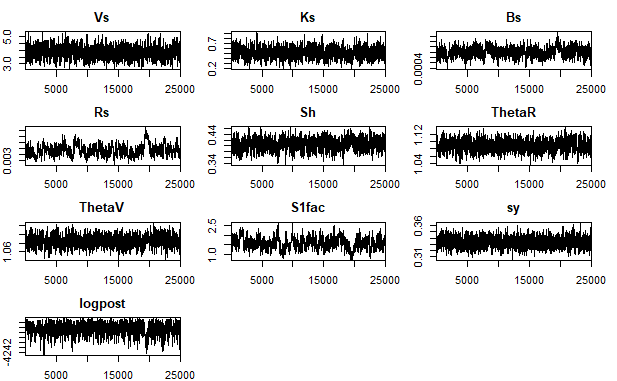

```r
cbind(RAM$samples,logpost= RAM$log.p) %>% as_tibble() %>%
  mutate(Vs=Vs/vs_scal,Bs=Bs/par_scal,Rs=Rs/par_scal,Sh = Sh-Sh_shift) %>% tail(25000) %>%
  as.matrix %>% sysanal.plot.chains()
dev.off()
```

# 13 Updated Model Parameters

The model parameters are updated based on the MCMC simulations.

```r
#Automatically set parameters
output_prm <- opt_prm
output_prm["Vs"] <- output_prm["Vs"]/vs_scal
output_prm["Bs"] <- output_prm["Bs"]/par_scal
output_prm["Rs"] <- output_prm["Rs"]/par_scal
output_prm["Sh"] <- output_prm["Sh"]-Sh_shift

# Posterior parameters central value
output_prm
```

```
         Vs          Ks          Bs          Rs          Sh      ThetaR
3.831364549 0.511863496 0.001008135 0.004725641 0.405246566 1.088230711
     ThetaV       S1fac          sy
1.084675465 1.567931444 0.333570497
```

# 14 Model Run

With the updated the parameters, the model is ran again to determine the phosphorus concentrations in the water column and sediments of the Jordan lake.

```r
#create output file using new model formulation
CalPar_lis <- list(
  Vs= output_prm["Vs"],Ks= output_prm["Ks"],Bs= output_prm["Bs"],Rs= output_prm["Rs"],
  Sh= output_prm["Sh"],
  ThetaR= output_prm["ThetaR"],ThetaV= output_prm["ThetaV"],
  S1fac= output_prm["S1fac"])

OmnInp <- c(CalPar_lis,inp_lis,Const_lis)
mod_cmpl <- suppressWarnings(lakemod_v0(user=OmnInp))
y_c <- mod_cmpl$run(tOd, tcrit = tmax)
y_c <- data.frame(y_c)

#create concentration columns that match observation data
y_c = merge(x = y_c,y = RoutMOdin[,c(2,3,4,5,6)],by = "t")
y_c$C1 <- (y_c$M1)/RoutMOdin$V1
y_c$C2all <- (y_c$M2)/RoutMOdin$V2
y_c$C3all <- (y_c$M3)/RoutMOdin$V3
y_c$C4all <- (y_c$M4)/RoutMOdin$V4

#do stratification fix here
y_c$C2=y_c$M2/RoutMOdin$V2*ConSurM[,"S2"]
y_c$C3=y_c$M3/RoutMOdin$V3*ConSurM[,"S3"]
y_c$C4=y_c$M4/RoutMOdin$V4*ConSurM[,"S4"]

#evaluate results, keep this in the code!
y_c_eval <- y_c[,c("yrmo","C1","C2","C3","C4")]
outm <- suppressWarnings(melt(y_c_eval, id.vars = "yrmo"))
colnames(outm) <- c("ym","variable","value")
outf <- outm %>%
  group_by(ym,variable) %>%
  suppressMessages(summarise(pre = mean(value, na.rm=T)))
outff <- merge(outm, obs, by = c("ym","variable"))
testLm = lm(obs~value,data = outff)
summary(testLm)
```

```
Call:
lm(formula = obs ~ value, data = outff)

Residuals:
    Min      1Q  Median      3Q     Max
-160.32  -14.72   -5.27   10.77  294.10

Coefficients:
            Estimate Std. Error t value Pr(>|t|)
(Intercept) 13.15370    1.95398   6.732 2.91e-11 ***
value        0.83658    0.02273  36.809  < 2e-16 ***
---
Signif. codes:  0 ‘***’ 0.001 ‘**’ 0.01 ‘*’ 0.05 ‘.’ 0.1 ‘ ’ 1

Residual standard error: 31.33 on 942 degrees of freedom
Multiple R-squared:  0.5899,    Adjusted R-squared:  0.5894
F-statistic:  1355 on 1 and 942 DF,  p-value: < 2.2e-16
```

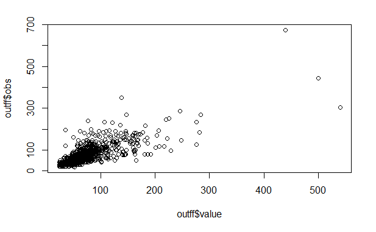

```r
plot(outff$value,outff$obs)
```

```r
#coeff of determination, R2
VarExp(outff[,"value"],outff[,"obs"])
```

```
[1] "0.567"
```

```r
######assemble the file
MassFlows = y_c
colnames(MassFlows) = c("t",
                        "M1","M2","M3","M4",
                        "S1","S2","S3","S4",
                        "mo","yrmo","Date","year",
                        "C1","C2","C3","C4",
                        "C2sur", "C3sur","C4sur")

#Input loadings to Segments
MassFlows$Seg1in = RoutMOdin$C1in*RoutMOdin$Q1in*(1-output_prm["Sh"])
MassFlows$Seg2in = RoutMOdin$C2in*RoutMOdin$Q2in*(1-output_prm["Sh"])
MassFlows$Seg3in = RoutMOdin$C3in*RoutMOdin$Q3in*(1-output_prm["Sh"])
MassFlows$Seg4in = RoutMOdin$C4in*RoutMOdin$Q4in*(1-output_prm["Sh"])

#Net Flows between Segments
MassFlows$Seg12 = MassFlows$C1*RoutMOdin$Q12 - MassFlows$C2*RoutMOdin$Q21
MassFlows$Seg23 = MassFlows$C2*RoutMOdin$Q23 - MassFlows$C3*RoutMOdin$Q32
MassFlows$Seg34 = MassFlows$C3*RoutMOdin$Q34 - MassFlows$C4*RoutMOdin$Q43
MassFlows$outflow = MassFlows$C4*RoutMOdin$Q4out

#Loading to Sediments
MassFlows$S1set = MassFlows$C1*(opt_prm["Ks"]*RoutMOdin$V1+output_prm["Vs"]*RoutMOdin$A1)*(output_prm["ThetaV"]^(RoutMOdin$Temperature-20))
MassFlows$S2set = MassFlows$C2*(opt_prm["Ks"]*RoutMOdin$V2+output_prm["Vs"]*RoutMOdin$A2)*(output_prm["ThetaV"]^(RoutMOdin$Temperature-20))
MassFlows$S3set = MassFlows$C3*(opt_prm["Ks"]*RoutMOdin$V3+output_prm["Vs"]*RoutMOdin$A3)*(output_prm["ThetaV"]^(RoutMOdin$Temperature-20))
MassFlows$S4set = MassFlows$C4*(opt_prm["Ks"]*RoutMOdin$V4+output_prm["Vs"]*RoutMOdin$A4)*(output_prm["ThetaV"]^(RoutMOdin$Temperature-20))

#resuspension of sediment TP
MassFlows$S1res = (MassFlows$S1*output_prm["Rs"])*(output_prm["ThetaR"]^(RoutMOdin$Temperature-20))
MassFlows$S2res = (MassFlows$S2*output_prm["Rs"])*(output_prm["ThetaR"]^(RoutMOdin$Temperature-20))
MassFlows$S3res = (MassFlows$S3*output_prm["Rs"])*(output_prm["ThetaR"]^(RoutMOdin$Temperature-20))
MassFlows$S4res = (MassFlows$S4*output_prm["Rs"])*(output_prm["ThetaR"]^(RoutMOdin$Temperature-20))

#Permanent Burial Rate
MassFlows$S1Bur = MassFlows$S1*output_prm["Bs"]
MassFlows$S2Bur = MassFlows$S2*output_prm["Bs"]
MassFlows$S3Bur = MassFlows$S3*output_prm["Bs"]
MassFlows$S4Bur = MassFlows$S4*output_prm["Bs"]

#temperature
MassFlows$Temp = RoutMOdin$Temperature

#cleanup
MassFlows = MassFlows[,c(1,12,13,10,
                        2,3,4,5,
                        6,7,8,9,
                        14:41)]
```

# 15 Skill of the model

We calculate the coefficient of determination (R<sup>2</sup>) and root mean square error (RMSE) for the model output to determine the skill of the model.

```r
# Overeall model performance
## Coefficient of determination
AllR2 <- VarExp(outff[,"value"],outff[,"obs"])
##  Root mean Square Error
AllRMSE <- sqrt(mean((outff$value - outff$obs)^2))/1000 # Units: mg/L

# Segment wise model performance
## Storing all the segment names in a vector for the loop
SegVec <- c("C1", "C2", "C3", "C4")
## Creating an empty data frame
PModPer <- data.frame(matrix(ncol = 3, nrow = 0)) %>% `colnames<-`(., c("Segment", "R2", "RMSE"))

## Loop to calculate R2 and RMSE for each segment
for (i in SegVec){
  Cx = i
  PobsSim <- outff[which(outff$variable==Cx),]
  CxR2 <- VarExp(PobsSim[,"value"],PobsSim[,"obs"])
  CxRMSE <- sqrt(mean((PobsSim$value - PobsSim$obs)^2))/1000 # units: mg/L
  TmpModPer <- data.frame(Segment = Cx, R2 = CxR2, RMSE = CxRMSE) # temporary df
  PModPer <- rbind(PModPer, TmpModPer)
}

## Adding overall model performance to the PModPer data frame
TmpModPerAll <- data.frame(Segment = "All", R2 = AllR2, RMSE = AllRMSE)
PModPer <- rbind(PModPer, TmpModPerAll)

# Quick view of the model performances
PModPer
```

| Segment | R2 | RMSE |
| --- | --- | --- |
| C1 | 0.467 | 0.04295085 |
| C2 | 0.334 | 0.01520130 |
| C3 | 0.294 | 0.01956083 |
| C4 | 0.297 | 0.03931024 |
| All | 0.567 | 0.03216838 |

```r
NA
```

# 16 Saving the workspace

```r
# Saving the Workspace (01-29-2023)
save.image("RWorkSpaces/JLPMv016p001_1.RData")
```

# 17 Data Visualization

The data visualization of the model results are carried out in subsequent part.

**Part 2:** 1. Prior and Posterior distribution 2. 1:1 Scatter plot 3. Mass Transfer plot 4. Sediment P release plot

```r
Tot_time1
```

```
Time difference of 2.781819 hours
```